# simple-resume-cv

Template for a simple resume or curriculum vitae (CV), in XeLaTeX.

**Compiled sample document:**  
CV.pdf

**Sample pages (click to enlarge):**

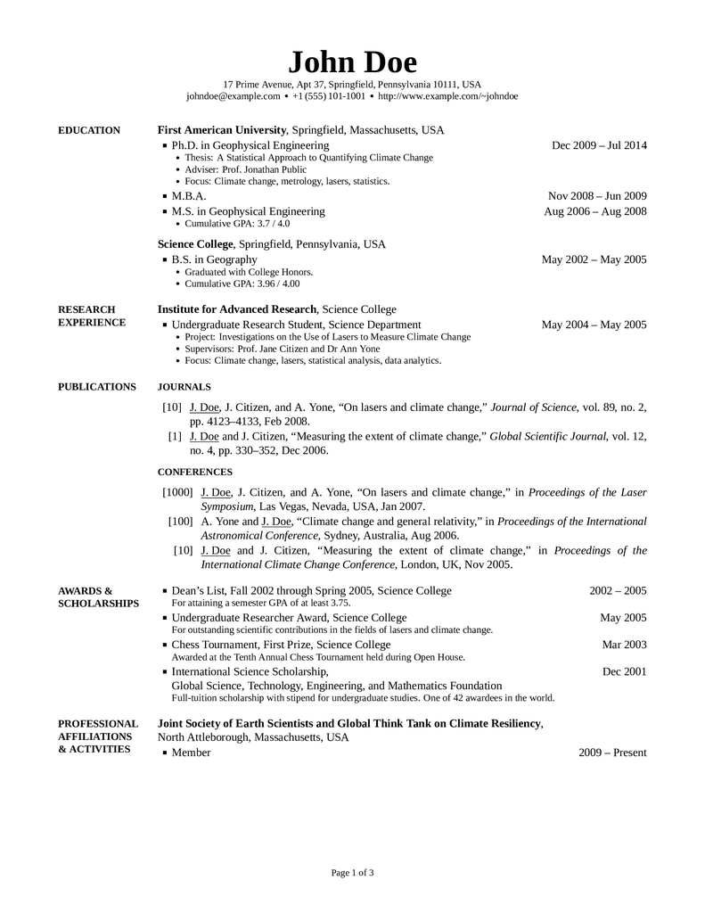

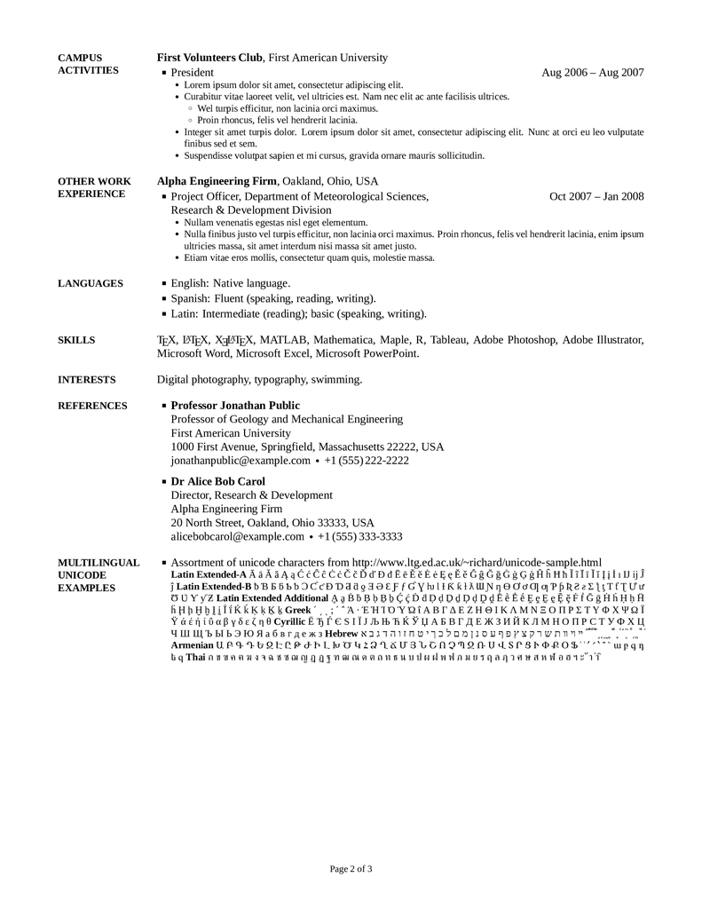

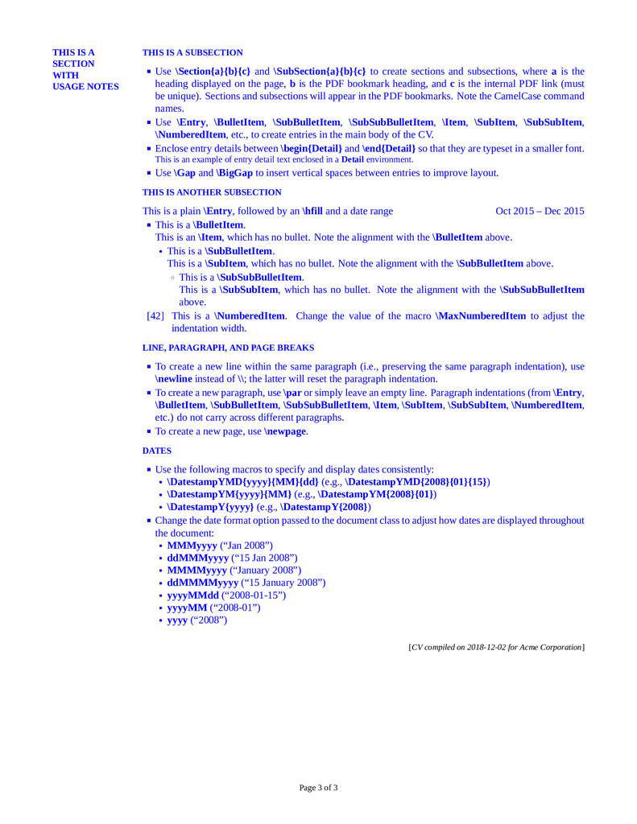

## Main Features

- Simple template that can be further customized or extended.
- Template document contains numerous examples.
- Direct support for TrueType (TTF) and OpenType (OTF) fonts.
- Direct support for multilingual Unicode characters, with the appropriate fonts.
- Hyperlinks can be included in generated PDF.

## Overview

The main XeLaTeX source file is `CV.tex`; the compiled document is `CV.pdf`.

Instructions for compiling the document (TeX →(XeLaTeX)→ PDF):

- **Method 1:** Use `latexmk` for fully automated document generation:
  - `latexmk -xelatex "CV.tex"` (add the `-pvc` switch to automatically recompile on changes)
- **Method 2:** Use `XeLaTeX` directly:
  - `xelatex "CV.tex"` (run multiple times to resolve cross-references if needed)

## License

This is free and unencumbered software released into the public domain. For more information, please see the file `LICENSE` or refer to http://unlicense.org.

## Recent Changes

- Release v3.0
  - Provides better support for other packages (e.g., biblatex) by removing the use of the longtable package for layout.
  - Note that this release introduces breaking changes; documents created using earlier releases of this template will need some minor changes to compile successfully.